# cMOVID19 - Informe Participantes 24 de junio 2020

[figure not shown]

**Miércoles 24 de junio, 2020**

## Cuarto informe de avance para participantes

Llevamos cerca de tres meses recolectando información semanal sobre el estado de salud de personas en el contexto de la crisis sanitaria por COVID-19 en Chile. Gracias a los aportes de los participantes MOVID-19, ya hemos podido entregar a la Mesa Social COVID-19 cinco informes con propuestas concretas para abordar la crisis sanitaria en nuestro país:

- [¿Cómo mejorar el aislamiento de casos COVID-19? Una mirada desde la respuesta del sistema de salud y las condiciones sociales](https://www.movid19.cl/informes/mesasocial1.html)
- [¿Cómo podemos mejorar nuestra capacidad de identificar casos COVID-19? Una mirada desde la epidemiología](https://www.movid19.cl/informes/mesasocial2.html)
- [¿Cuál ha sido la respuesta de la población a las cuarentenas? El impacto de las desigualdades en la efectividad de las politicas sanitarias](https://www.movid19.cl/informes/mesasocial3.html)
- [¿Cómo podemos reducir las barreras del sistema de salud para incrementar el diagnóstico precoz de casos COVID-19? Una mirada desde el acceso a servicios de salud](https://www.movid19.cl/informes/mesasocial4.html)
- [¿Cómo podemos reducir el efecto negativo de la crisis sanitaria para mujeres y trabajadoras de la salud? Una mirada desde una perspectiva de género](https://www.movid19.cl/informes/mesasocial5.html)

### Qué más hemos aprendido

En este cuarto informe de avance para participantes queremos destacar la necesidad de **respetar las medidas de aislamiento, especialmente cuando se presenta sintomatología compatible con COVID-19**. Esto es fundamental para evitar poner en riesgo la salud del resto de la población, permitiendo reducir la multiplicación de contagios.

En este informe reportamos resultados de 4.147 observaciones MOVID-19 que cumplen con sintomatología compatible con COVID-19. Se observa que las personas con sintomatología sospechosa de COVID-19 que salen de sus hogares han disminuido con la evolución de la pandemia, pasando de un 100% de en la semana del 13 de abril, a un 64% de los casos en la semana del 8 de junio (ver Figura 1). No obstante, el porcentaje de personas con síntomas compatibles con COVID-19 que no permanece en aislamiento sigue siendo elevado. **Resulta fundamental consultar ante síntomas compatibles y evaluar formas de mantenerse aislado en caso de sospechar la presencia de COVID-19**.

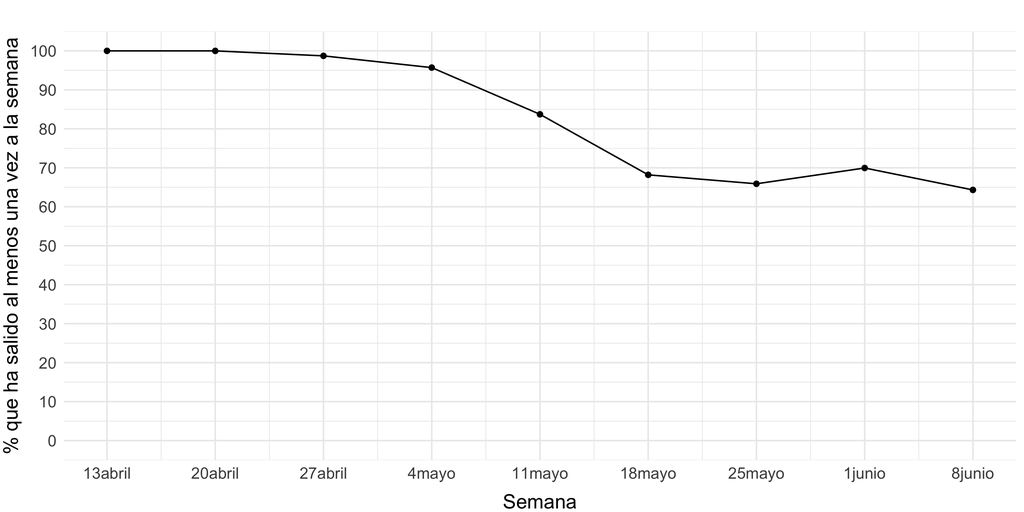

*Figura 1*. Porcentaje de personas con síntomas compatibles con COVID-19 que han salido de su hogar al menos una vez en la semana. Análisis propio realizado en base 4.147 observaciones de casos sospechosos entre los participantes MOVID-19.

### Síntomas compatibles o situaciones de riesgo de tener COVID-19

Las siguientes situaciones son compatibles con enfermedad por COVID-19:

- Que aparezcan como síntomas nuevos, cualquier combinación de al menos dos de los siguientes síntomas: tos, diarrea, dolor de garganta (odinofagia) o dolor de cabeza (cefalea).
- Tener contacto estrecho con un paciente confirmado mediante PCR durante los últimos 14 días.
- Presentar fiebre (temperatura axilar mayor a 37.8ºC), sin otra causa evidente que pueda explicarlo.
- Presentar manifestación aguda de disminución o perdida del olfato (anosmia).

### Qué hacer si tiene síntomas compatibles con COVID-19

Cualquier persona que tenga sintomatología compatible con COVID-19 deberá iniciar de manera inmediata un aislamiento para evitar contagiar a otros. Esto implica evitar salir de su hogar, mantener distancia física de al menos dos metros con cualquier otra persona, usar mascarilla en todo momento, no compartir articulos personales con otros miembros del hogar. Así mismo, de ser posible debe evitar compartir habitación con otras personas. Con estas medidas usted estará contribuyendo a evitar que sus seres queridos u otras personas puedan contagiarse. Está en nosotros contribuir a disminuir el riesgo de contagios.

### Cómo seguir aportando

MOVID-19 está entregando información relevante para entender y controlar la crisis sanitaria que hoy está viviendo nuestro país. Para continuar este gran esfuerzo, necesitamos de su colaboración:

- Siga completando de manera semanal su situación actual de salud. Esta información es importante, sin importar si su situación ha cambiado o si se mantiene igual. Su actualización es fundamental aunque no tenga síntomas y esté cumpliendo con las medidas de aislamiento. Cuando sea el momento de contestar, le enviaremos un correo electrónico con una invitación dedicada para Ud.
- Invite a más personas a participar. Comparta el vínculo http://encuestacovid.uchile.cl en su comunidad, lugar de trabajo o estudio, a sus amigos o familia. Necesitamos llegar a la mayor cantidad de personas mayores de 18 años que viven en Chile.
- ¡Siga manteniendo distancia física y quédandose en casa lo más posible!

### ¡Esta pandemia la enfrentamos entre todas y todos!

Gracias por seguir participando en MOVID-19,

**Equipo MOVID-19**  
**Colegio Médico de Chile**  
**Universidad de Chile**

**Institución asociada: Facultad de Psicología, Universidad Diego Portales**

**Contacto: encuestacovid@uchile.cl**